# Rendimiento de beisbol

Arisbel Flores Ariza

2025-05-26

## Introducción

El beisbol es un deporte conocido a nivel mundial que ha generado una gran cantidad de datos estadísticos. Dentro de este análisis se busca conocer la relación entre la cantidad de carreras realizadas por los jugadores de acuerdo con la cantidad de veces en que jugaron. Para lograr lo anterior se analizó la infomación contenida en el dataset baseball_hitting.csv

## Cargar paquetes necesarios

```r
library(tidyr)
library(ggplot2)
library(dplyr)
library(plotly)
library(ggthemes)
```

## Exploración y limpieza de datos

Con el objetivo de analizar estos datos se llevo a cabo una exploración de la información contenida, se determino el tipo de variables presentes y se realizo un resúmen estadístico. Con lo anterior, se buscaron valores faltantes que posteriormente fueron eliminados para una mejor visualización de la información.

```
##   Player.name position Games At.bat Runs Hits Double..2B. third.baseman
## 1     B Bonds       LF  2986   9847 2227 2935         601            77
## 2     H Aaron       RF  3298  12364 2174 3771         624            98
## 3      B Ruth       RF  2504   8399 2174 2873         506           136
## 4    A Pujols       1B  3080  11421 1914 3384         686            16
## 5 A Rodriguez       SS  2784  10566 2021 3115         548            31
## 6      W Mays       CF  2992  10881 2062 3283         523           140
##   home.run run.batted.in a.walk Strikeouts stolen.base Caught.stealing   AVG
## 1      762          1996   2558       1539         514             141 0.298
## 2      755          2297   1402       1383         240              73 0.305
## 3      714          2213   2062       1330         123             117 0.342
## 4      703          2218   1373       1404         117              43 0.296
## 5      696          2086   1338       2287         329              76 0.295
## 6      660          1903   1464       1526         338             103 0.302
##   On.base.Percentage Slugging.Percentage On.base.Plus.Slugging
## 1              0.444               0.607                 1.051
## 2              0.374               0.555                 0.929
## 3              0.474               0.690                 1.164
## 4              0.374               0.544                 0.918
## 5              0.380               0.550                 0.930
## 6              0.384               0.557                 0.941
```

```
## 'data.frame':    2508 obs. of  18 variables:
##  $ Player.name          : chr  "B Bonds" "H Aaron" "B Ruth" "A Pujols" ...
##  $ position             : chr  "LF" "RF" "RF" "1B" ...
##  $ Games                : int  2986 3298 2504 3080 2784 2992 2671 2543 2354 2808 ...
##  $ At.bat               : int  9847 12364 8399 11421 10566 10881 9801 8422 8813 10006 ...
##  $ Runs                 : int  2227 2174 2174 1914 2021 2062 1662 1583 1475 1829 ...
##  $ Hits                 : int  2935 3771 2873 3384 3115 3283 2781 2328 2408 2943 ...
##  $ Double..2B.          : int  601 624 506 686 548 523 524 451 379 528 ...
##  $ third.baseman        : int  77 98 136 16 31 140 38 26 45 72 ...
##  $ home.run             : int  762 755 714 703 696 660 630 612 609 586 ...
##  $ run.batted.in        : int  1996 2297 2213 2218 2086 1903 1836 1699 1667 1812 ...
##  $ a.walk               : int  2558 1402 2062 1373 1338 1464 1312 1747 929 1420 ...
##  $ Strikeouts           : chr  "1539" "1383" "1330" "1404" ...
##  $ stolen.base          : int  514 240 123 117 329 338 184 19 234 204 ...
##  $ Caught.stealing      : chr  "141" "73" "117" "43" ...
##  $ AVG                  : num  0.298 0.305 0.342 0.296 0.295 0.302 0.284 0.276 0.273 0.294 ...
##  $ On.base.Percentage   : num  0.444 0.374 0.474 0.374 0.38 0.384 0.37 0.402 0.344 0.389 ...
##  $ Slugging.Percentage  : num  0.607 0.555 0.69 0.544 0.55 0.557 0.538 0.554 0.534 0.537 ...
##  $ On.base.Plus.Slugging: num  1.051 0.929 1.164 0.918 0.93 ...
```

```
##    Length     Class      Mode
##         1 character character
```

```
## [1] TRUE
```

```
## [1] 124
```

```
##           Player.name              position                 Games
##                     0                     0                     8
##                At.bat                  Runs                  Hits
##                     8                     8                     8
##           Double..2B.         third.baseman              home.run
##                     8                     8                     8
##         run.batted.in                a.walk            Strikeouts
##                     8                     8                     0
##           stolen.base       Caught.stealing                   AVG
##                     8                     0                     8
##    On.base.Percentage   Slugging.Percentage On.base.Plus.Slugging
##                     8                     8                    20
```

## Carreras realizadas - Diagrama de dispersión

**Análisis** La tendencia general nos muestra que a mayor número de juegos incremeta el total de carreras realizadas por jugador, sin embargo, hay presencia de valores atípicos. Lo anterior, nos indica que hay jugadores que consiguieron un mayor número de carreras anotadas estando en menos juegos, esto habla de un mejor rendimiento de juego.

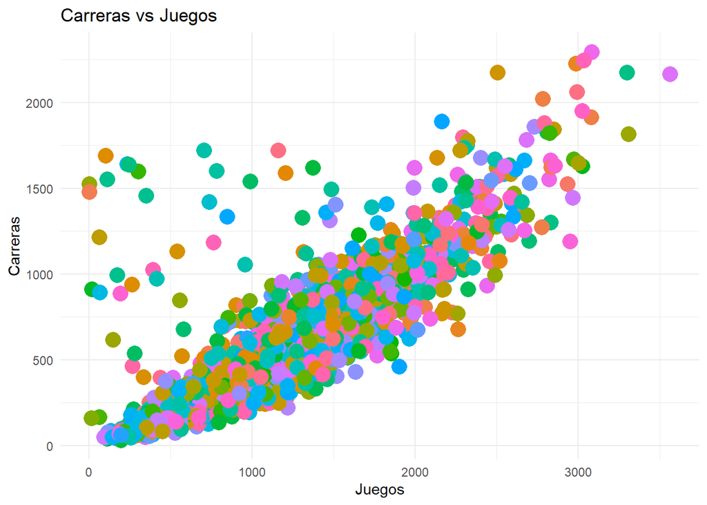

```r
#1ro. Diagrama de dispersión que me permita visualizar la siguiente hipótesis: "A mayor número de juegos mayor número de carreras"
ggplot(data_limpios, aes(x = Juegos, y = Carreras, color = Player.name)) +
  geom_point(size =5) +
  labs(title = "Carreras vs Juegos",
       x = "Juegos",
       y = "Carreras",
       color = "Jugador") +
  guides(color = "none") +
  theme_minimal()
```

## Frecuencia de los Home Runs - Histograma

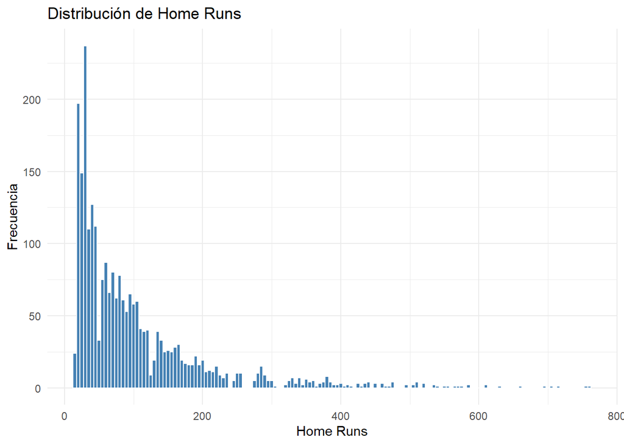

```r
#2do. Histograma para ver la distribución de la variable home.run
ggplot(data_limpios,aes(x = home.run)) +
  geom_histogram(binwidth = 5, fill = "steelblue", color = "white") +
  labs(title = "Distribución de Home Runs",
       x ="Home Runs",
       y = "Frecuencia") +
  theme_minimal()
```

## Conclusiones

Con el análisis realizado se puede concluir que hay una correlación positiva entre la cantidad de carreras realizados con el total de juegos en que estuvieron los jugadores. Así como podemos concluir que hay mayor frecuencia de jugadores que realizan hasta 70 home runs, disminuyendo tal frecuencia conforme el número de home runs anotados aumenta. Finalmente, como una posible línea futura de análisis se rescata la importancia de observar la relación entre las carreras anotadas de acuerdo con los juegos en que estuvieron presentes los jugadores debido a que esto representa el rendimiento del jugador frente a un deporte tan demandante como es el baseball.